# Homework3

8. FITTING THE MODEL

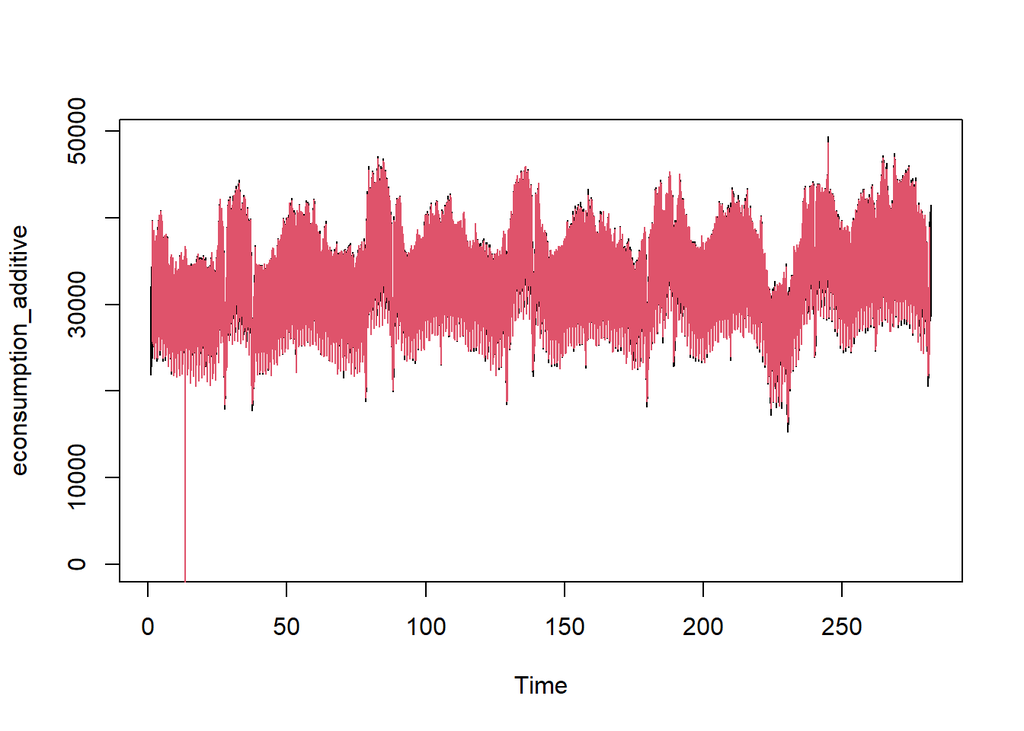

```r
model_fitted <- consumption_additive_decomposition$random - model4$residuals
model_transformed <- model_fitted + consumption_additive_decomposition$seasonal + consumption_additive_decomposition$trend

plot(econsumption_additive, type='l')
points(model_transformed, type = 'l', col=2)
```

9. FORECAST

We will make the forecasts starting from the 6 May 2021 to 20 May 2021. Since we are making hourly predictions, we need to make 336 (24*14) units ahead forecasts. We will use the last trend value and the latest seasonal values.

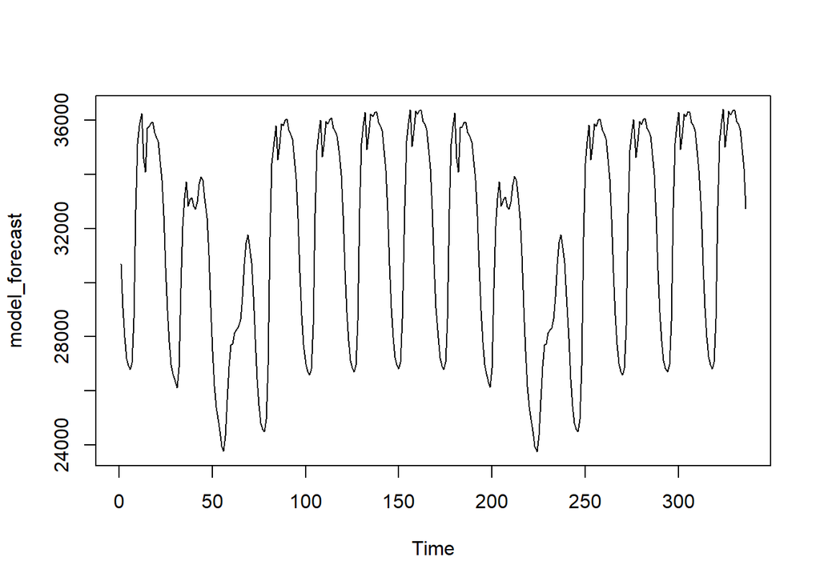

```r
model_forecast <- predict(model4, n.ahead = 336)$pred
model_forecast <- ts(model_forecast)

last_trend_value <- tail(consumption_additive_decomposition$trend[!is.na(consumption_additive_decomposition$trend)],1)
seasonality <- consumption_additive_decomposition$seasonal[46873:47208]

model_forecast <- model_forecast + seasonality + last_trend_value
plot(model_forecast)
```

10. ERROR CALCULATIONS

```r
actual_data <- econsumption$Consumption[46873:47208]
test_data <- data.frame(actual_data,model_forecast)
test_data <- data.table(test_data)

test_data[,Error:=actual_data - model_forecast]
test_data[,AbsError:=abs(Error)]
test_data[,Bias:=Error/actual_data]
test_data[,Ape:=AbsError/actual_data]

test_data
```

```
##      actual_data model_forecast    Error AbsError       Bias        Ape
##   1:    34407.89       30675.12 3732.767 3732.767 0.10848578 0.10848578
##   2:    32984.77       29074.02 3910.751 3910.751 0.11856232 0.11856232
##   3:    32736.92       27987.02 4749.900 4749.900 0.14509308 0.14509308
##   4:    31913.44       27198.57 4714.874 4714.874 0.14773946 0.14773946
##   5:    31318.70       26959.45 4359.245 4359.245 0.13918985 0.13918985
##  ---
## 332:    37793.51       35858.33 1935.178 1935.178 0.05120396 0.05120396
## 333:    38805.79       35636.03 3169.760 3169.760 0.08168267 0.08168267
## 334:    38413.45       34938.99 3474.457 3474.457 0.09044897 0.09044897
## 335:    37630.77       34226.59 3404.183 3404.183 0.09046274 0.09046274
## 336:    36126.55       32732.28 3394.266 3394.266 0.09395488 0.09395488
```

```r
mape=sum(test_data$AbsError/actual_data)/336

mad= sum(test_data$AbsError)/336

wmape= mad/mean(actual_data)
c(mape=mape, mad=mad, wmape=wmape)
```

```
##         mape          mad        wmape
##    0.1132729 3360.9978486    0.1058733
```

Although there are some days that error and deviance values are high, in overall, statistics are relatively small enough.

11. CONCLUSION

In that report, the electricity consumption of Turkey between 01.01.2016 and 05.20.2021 was studied. At the beginning, we tried to make the data stationary as much as possible. Data was decomposed at different time levels and an appropriate frequency (168) is chosen. Then, the AR and MA models have created. After the seperate AR-MA models, the ARMA model is chosen with the best possible p and q (4,4) values. With this ARMA model, we made a 14 day forecast of total electricity consumption of Turkey. Finally, we evaluated the model created and calculated the error statistics.